# Student's Path Analysis

**Research question**. Are there significant differences between students who take a total number of credits greater than or equal to 40 and those who take less than 40 credits, one year after enrolling, in terms of the order in which they take certain subjects?

We will perform the analysis on a subset of students, i.e. those enrolled in program ID 8009, and by differentiating the results by year of enrollment and by gender. We will calculate the statistical significance of the differences between the two groups of students.

To perform the analysis, I'll follow these steps:

1. **Data Exploration**: I'll start by loading the dataset to understand its structure, including the columns and types of data it contains.
2. **Data Preparation**: I'll focus on filtering the dataset for students enrolled in program ID 8009, and prepare the data for further analysis.
3. **Grouping and Analysis**: I'll categorize the students based on the number of credits they've taken (40 or more 40 vs. less than 40) and analyze the order in which they take certain subjects.
4. **Statistical Significance Testing**: I'll calculate the statistical significance of any differences found between the two groups.
5. **Segmentation by Year of Enrollment and Gender**: I'll repeat the analysis by further segmenting the data by year of enrollment and gender.

## Data Exploration

```python
from data.config import *
import pandas as pd
import os
# suppress warnings
import warnings
warnings.filterwarnings('ignore')

# Load the dataset
data = pd.read_csv(os.path.join(data_dir, "exams.csv"))

# Display the first few rows of the dataset to understand its structure
data.head(2)
```

|  | StudentID | Gender | EnrolmentDate | SubjectID | Credits | ExamDate | Grade | ProgramID |
| --- | --- | --- | --- | --- | --- | --- | --- | --- |
| 0 | 1 | Male | 2017-10-31 | 74790.0 | 13 | 2018-02-12 | 27 | 8514 |
| 1 | 1 | Male | 2017-10-31 | 63708.0 | 12 | 2018-02-21 | 27 | 8514 |

The dataset contains the following columns:

1. **StudentID**: Identifier for each student.
2. **Gender**: Gender of the student.
3. **EnrolmentDate**: Date when the student enrolled.
4. **SubjectID**: Identifier for the subjects taken.
5. **Credits**: Number of credits for each subject.
6. **ExamDate**: Date when the exam for each subject was taken.
7. **Grade**: Grade achieved in each subject.
8. **ProgramID**: Identifier for the program in which the student is enrolled.

## Data Preparation

Next, we will proceed to the Data Preparation step. Here, we will:

- Filter the data for students enrolled in the Program ID 8009.
- Convert `EnrolmentDate` and `ExamDate` into datetime format for easier manipulation.

```python
# Convert EnrolmentDate and ExamDate to datetime
data['EnrolmentDate'] = pd.to_datetime(data['EnrolmentDate'])
data['ExamDate'] = pd.to_datetime(data['ExamDate'])

# Filter for students in the Program ID 8009
cs_data = data[data['ProgramID'] == 8009]
```

The next steps in the Data Preparation phase will include:

1. **Calculating Total Credits**: For each student, I'll calculate the total number of credits they have taken in the first year after their enrollment.
2. **Categorizing Students Based on Credits**: Students will be categorized into two groups based on whether they have taken more or 40 credits or less than 40 credits in their first year.
3. **Preparing Data for Subject Order Analysis**: I'll organize the data to analyze the order in which subjects were taken by these two groups of students.

```python
# Calculate the total credits for each student in the first year after enrollment
cs_data['YearAfterEnrollment'] = cs_data['ExamDate'].dt.year - \
    cs_data['EnrolmentDate'].dt.year
first_year_data = cs_data[cs_data['YearAfterEnrollment'] <= 1]

# Sum the credits for each student
total_credits_first_year = first_year_data.groupby(
    'StudentID')['Credits'].sum().reset_index()

# Categorize students based on credits
total_credits_first_year['CreditsCategory'] = total_credits_first_year['Credits'].apply(
    lambda x: '>=40' if x >= 40 else '<40')

# Merge this information back with the main data
cs_data_with_credits_category = pd.merge(cs_data, total_credits_first_year[[
                                         'StudentID', 'CreditsCategory']], on='StudentID')

# SubjectID is represented as integer, not float
cs_data_with_credits_category['SubjectID'] = cs_data_with_credits_category['SubjectID'].astype(
    int)

# Display the first few rows of the modified dataset
cs_data_with_credits_category.head(2)
```

|  | StudentID | Gender | EnrolmentDate | SubjectID | Credits | ExamDate | Grade | ProgramID | YearAfterEnrollment | CreditsCategory |
| --- | --- | --- | --- | --- | --- | --- | --- | --- | --- | --- |
| 0 | 231 | Male | 2016-10-31 | 819 | 12 | 2017-01-16 | 29 | 8009 | 1 | <40 |
| 1 | 231 | Male | 2016-10-31 | 11925 | 6 | 2017-02-21 | 25 | 8009 | 1 | <40 |

## Grouping and Analysis of Subject Order

Next, we'll prepare the data to analyze the order in which subjects were taken by these two groups of students. This will involve:

1. **Sorting Data by Exam Date**: For each student, sort their subjects based on the `ExamDate`.
2. **Analyzing Subject Order**: Determine the sequence in which subjects were taken by students in the two credit categories.

```python
# Sorting the data by StudentID and ExamDate
cs_data_sorted = cs_data_with_credits_category.sort_values(
    by=['StudentID', 'ExamDate'])

# Display the first few rows to verify the sorting
cs_data_sorted.head(4)
```

|  | StudentID | Gender | EnrolmentDate | SubjectID | Credits | ExamDate | Grade | ProgramID | YearAfterEnrollment | CreditsCategory |
| --- | --- | --- | --- | --- | --- | --- | --- | --- | --- | --- |
| 0 | 231 | Male | 2016-10-31 | 819 | 12 | 2017-01-16 | 29 | 8009 | 1 | <40 |
| 1 | 231 | Male | 2016-10-31 | 11925 | 6 | 2017-02-21 | 25 | 8009 | 1 | <40 |
| 2 | 231 | Male | 2016-10-31 | 66857 | 6 | 2017-06-12 | 22 | 8009 | 1 | <40 |
| 3 | 231 | Male | 2016-10-31 | 13 | 12 | 2017-09-07 | 20 | 8009 | 1 | <40 |

The data is now sorted by `StudentID` and `ExamDate`, which allows us to see the sequence in which each student took their subjects.

Here are the steps we will perform to analyze the order in which subjects were taken by the two groups of students:

1. **Identify Common Subjects**: We'll find the most frequently taken subjects within each credits category (>=40 and <40). This will help us focus on subjects that are commonly taken by a significant number of students in both groups.
2. **Analyze Subject Sequence**: For the common subjects identified, we will analyze the typical sequence in which they are taken. This involves looking at the order of these subjects for students in each credit category.
3. **Statistical Significance Testing**: After identifying any notable differences in the sequence of subject completion between the two groups, we will conduct statistical tests to determine if these differences are statistically significant.
4. **Segmentation by Year of Enrollment and Gender**: Finally, we'll repeat the analysis, further segmenting the data by year of enrollment and gender, to see if these factors influence the order of subject completion.

We will now proceed with the first step: Identifying the most common subjects taken by each group.

```python
# Identifying the most common subjects in each credits category

# Group by CreditsCategory and SubjectID, then count the occurrences
subject_frequency = cs_data_sorted.groupby(
    ['CreditsCategory', 'SubjectID']).size().reset_index(name='Count')

# For each CreditsCategory, find the most common  (9, empirically) subjects
most_common_subjects = subject_frequency.sort_values(
    ['CreditsCategory', 'Count'], ascending=[True, False]).groupby('CreditsCategory').head(9)

most_common_subjects
```

|  | CreditsCategory | SubjectID | Count |
| --- | --- | --- | --- |
| 3 | <40 | 11925 | 268 |
| 0 | <40 | 13 | 173 |
| 1 | <40 | 405 | 122 |
| 7 | <40 | 58414 | 100 |
| 8 | <40 | 66857 | 93 |
| 2 | <40 | 819 | 87 |
| 4 | <40 | 26338 | 45 |
| 9 | <40 | 93283 | 21 |
| 5 | <40 | 37635 | 4 |
| 13 | >=40 | 11925 | 149 |
| 10 | >=40 | 13 | 146 |
| 12 | >=40 | 819 | 138 |
| 16 | >=40 | 58414 | 122 |
| 17 | >=40 | 66857 | 116 |
| 11 | >=40 | 405 | 94 |
| 15 | >=40 | 37635 | 65 |
| 19 | >=40 | 93283 | 24 |
| 14 | >=40 | 26338 | 16 |

The most common subjects taken by students in each credit category have been identified.

The next step is to analyze the sequence in which these common subjects were taken by the students in each group:

1. **Filter Data for Common Subjects**: Focus on the exam records of students who have taken these common subjects.
2. **Determine Subject Sequence**: For each student, determine the order in which they took these common subjects.
3. **Aggregate the Sequence Information**: Compile this information to understand typical patterns in the sequence of subject completion for each credit category.

We will start with the first step: filtering the data for these common subjects.

```python
# Filtering the data for the most common subjects
common_subject_ids = most_common_subjects['SubjectID'].unique()
filtered_data = cs_data_sorted[cs_data_sorted['SubjectID'].isin(
    common_subject_ids)]

# Determining the sequence of these subjects for each student
# We create a new column that indicates the order in which the subjects were taken
filtered_data['SubjectOrder'] = filtered_data.groupby(
    'StudentID').cumcount() + 1

# Focus on the relevant columns for analysis
sequence_data = filtered_data[['StudentID',
                               'CreditsCategory', 'SubjectID', 'SubjectOrder']]

# Display the first few rows to verify the sequence
sequence_data.head(4)
```

|  | StudentID | CreditsCategory | SubjectID | SubjectOrder |
| --- | --- | --- | --- | --- |
| 0 | 231 | <40 | 819 | 1 |
| 1 | 231 | <40 | 11925 | 2 |
| 2 | 231 | <40 | 66857 | 3 |
| 3 | 231 | <40 | 13 | 4 |

The data is now filtered to focus on the most common subjects, and a new column `SubjectOrder` has been added to indicate the sequence in which each student took these subjects.

The next steps are:

1. **Aggregate the Sequence Information**: For each credit category, we will compile the sequence information to understand common patterns in the order of subject completion.
2. **Comparison of Sequences Between Credit Categories**: Compare the typical subject sequence between students who took more or 40 credits and those who took less than 40 credits.

```python
# Aggregating sequence information for each credit category

# Group by CreditsCategory, SubjectID, and SubjectOrder, then count the occurrences
sequence_aggregated = sequence_data.groupby(
    ['CreditsCategory', 'SubjectID', 'SubjectOrder']).size().reset_index(name='Count')

# Sorting the data to better understand the sequence pattern
sequence_sorted = sequence_aggregated.sort_values(
    ['CreditsCategory', 'SubjectID', 'SubjectOrder'])

# Displaying the first few rows to observe the pattern
sequence_sorted.head(5)
```

|  | CreditsCategory | SubjectID | SubjectOrder | Count |
| --- | --- | --- | --- | --- |
| 0 | <40 | 13 | 1 | 20 |
| 1 | <40 | 13 | 2 | 53 |
| 2 | <40 | 13 | 3 | 61 |
| 3 | <40 | 13 | 4 | 30 |
| 4 | <40 | 13 | 5 | 9 |

The sequence information has been aggregated, showing how often each subject was taken as the 1st, 2nd, 3rd, etc., by students in each credit category.

The next step is to compare these sequences between the two credit categories to identify any significant differences in the order of subject completion. This comparison will provide insight into whether students who take more credits tend to follow a different trajectory in their subject choices compared to those who take fewer credits.

To compare the sequences between the two credit categories, we will:

1. **Analyze Sequence Patterns**: Look for patterns in the order of subject completion between the two groups.
2. **Identify Differences**: Highlight any notable differences in the sequence in which the most common subjects are taken.

```python
# Analyzing sequence patterns and identifying differences between the two credit categories

# To better understand the differences, we'll pivot the data for comparison
pivot_sequence = sequence_sorted.pivot_table(index=['SubjectID', 'SubjectOrder'],
                                             columns='CreditsCategory',
                                             values='Count',
                                             fill_value=0)

# Resetting index for clarity
pivot_sequence.reset_index(inplace=True)

# Sorting the data for a clearer comparison
pivot_sequence_sorted = pivot_sequence.sort_values(
    ['SubjectID', 'SubjectOrder'])

# Displaying the first few rows for comparison
pivot_sequence_sorted.head(6)
```

| CreditsCategory | SubjectID | SubjectOrder | <40 | >=40 |
| --- | --- | --- | --- | --- |
| 0 | 13 | 1 | 20.0 | 0.0 |
| 1 | 13 | 2 | 53.0 | 7.0 |
| 2 | 13 | 3 | 61.0 | 48.0 |
| 3 | 13 | 4 | 30.0 | 49.0 |
| 4 | 13 | 5 | 9.0 | 29.0 |
| 5 | 13 | 6 | 0.0 | 13.0 |

The pivot table provides a side-by-side comparison of the order in which the most common subjects were taken by students in the two credit categories.

The next step would be to perform statistical tests to determine the significance of the differences. To determine the statistical significance of the observed differences in subject sequence between the two credit categories, we will use the chi-square test for independence. This test is appropriate for categorical data such as ours and will help us determine if the differences in sequence patterns are statistically significant.

The steps for this test are

1. **Chi-square test for each subject**: We will perform a chi-square test for each common subject to see if there is a significant difference in the sequence pattern between the two credit categories.
2. **Interpreting the results**: We will interpret the results to understand which subjects, if any, show a statistically significant difference in sequence pattern.

```python
from scipy.stats import chi2_contingency

# Function to perform Chi-Square Test


def perform_chi_square_test(data, subject_id):
    # Extracting data for a specific subject
    subject_data = data[data['SubjectID'] == subject_id]

    # Dropping the subject ID and SubjectOrder as they are not needed for the test
    contingency_table = subject_data.drop(
        columns=['SubjectID', 'SubjectOrder'])

    # Performing the Chi-Square test
    _, p, _, _ = chi2_contingency(contingency_table)
    return p


# Performing Chi-Square test for each common subject and storing the p-values
p_values = {}
for subject_id in common_subject_ids:
    p_values[subject_id] = perform_chi_square_test(
        pivot_sequence_sorted, subject_id)

p_values
```

```
{11925: 7.475478102915605e-05,
 13: 1.7737359232905143e-16,
 405: 3.9823613825426335e-09,
 58414: 1.7072795842265356e-11,
 66857: 0.35061522583901106,
 819: 1.9406944838908414e-12,
 26338: 0.034687533145943424,
 93283: 0.7507883482197641,
 37635: 1.0017614581966652e-09}
```

## Segmentation by Year of Enrollment and Gender

The next step would be to perform this analysis segmented by year of enrollment and gender to see if these factors influence the order in which subjects are enrolled.

To perform the segmented analysis by year of enrollment, we will:

1. **Segment the data by year of enrollment**: Segment the data based on the year students enrolled.
2. **Repeat Sequence Analysis**: For each enrollment year segment, repeat the sequence analysis to see if the pattern of subject completion varies by year.
3. **Statistical Significance Tests**: Perform statistical tests for each segment to determine if any observed differences are statistically significant.

```python
# Extracting the year of enrollment
cs_data_sorted['EnrollmentYear'] = cs_data_sorted['EnrolmentDate'].dt.year

# Segmenting the data by enrollment year
enrollment_year_segments = cs_data_sorted['EnrollmentYear'].unique()

sequence_analysis_by_year = {}

for year in enrollment_year_segments:
    year_data = cs_data_sorted[cs_data_sorted['EnrollmentYear'] == year]
    # Adding the 'SubjectOrder' column
    year_data['SubjectOrder'] = year_data.groupby('StudentID').cumcount() + 1
    # Filtering for common subjects
    year_data_filtered = year_data[year_data['SubjectID'].isin(
        common_subject_ids)]
    # Performing the sequence analysis
    year_data_sequence = year_data_filtered.groupby(
        ['CreditsCategory', 'SubjectID', 'SubjectOrder']).size().reset_index(name='Count')
    sequence_analysis_by_year[year] = year_data_sequence

# Displaying the sequence analysis for the first enrollment year as an example
sequence_analysis_by_year[enrollment_year_segments[0]].head(4)
```

|  | CreditsCategory | SubjectID | SubjectOrder | Count |
| --- | --- | --- | --- | --- |
| 0 | <40 | 13 | 1 | 5 |
| 1 | <40 | 13 | 2 | 10 |
| 2 | <40 | 13 | 3 | 12 |
| 3 | <40 | 13 | 4 | 5 |

The sequence analysis for each enrollment year has been successfully performed, given the common subjects and their order of completion.

The next step would be to perform statistical tests for each year segment to determine if the differences in sequences are statistically significant, similar to the overall analysis we performed earlier.

To perform the statistical significance tests for each enrollment year segment, we:

1. Create **contingency tables**: For each year and each common subject, create contingency tables showing the pattern of sequences in the two credit categories.
2. **Run Chi-Square Tests**: Perform chi-square tests for independence on these tables to determine if there are statistically significant differences in the sequence patterns.
3. **Gather Results**: Collect and interpret the p-values from these tests for each year and subject.

```python
# Function to perform Chi-Square Test for each year segment
def chi_square_test_for_year(year_data, subject_ids):
    p_values_year = {}
    for subject_id in subject_ids:
        # Preparing the contingency table for the subject
        subject_data = year_data[year_data['SubjectID'] == subject_id]
        pivot_subject = subject_data.pivot_table(index=['SubjectOrder'],
                                                 columns='CreditsCategory',
                                                 values='Count',
                                                 fill_value=0)
        # Performing the Chi-Square test
        _, p, _, _ = chi2_contingency(pivot_subject)
        p_values_year[subject_id] = p
    return p_values_year


# Verifying data availability for each subject in each year segment
data_availability_by_year = {}

for year in enrollment_year_segments:
    year_data = sequence_analysis_by_year[year]
    available_subjects = year_data['SubjectID'].unique()
    data_availability_by_year[year] = available_subjects

# Performing Chi-Square tests for all years
p_values_for_all_years = {}

# Skipping the first year as it's already done
for year in enrollment_year_segments:
    year_data = sequence_analysis_by_year[year]
    p_values_year = {}
    for subject_id in common_subject_ids:
        # Checking if the subject is present in the year segment
        if subject_id in data_availability_by_year[year]:
            subject_data = year_data[year_data['SubjectID'] == subject_id]
            # Preparing the contingency table for the subject
            pivot_subject = subject_data.pivot_table(index=['SubjectOrder'],
                                                     columns='CreditsCategory',
                                                     values='Count',
                                                     fill_value=0)
            # Perform the Chi-Square test if there are enough data
            if pivot_subject.size > 0:
                chi2, p, dof, expected = chi2_contingency(pivot_subject)
                p_values_year[subject_id] = p
    p_values_for_all_years[year] = p_values_year

# order keys in ascending order
p_values_for_all_years = dict(sorted(p_values_for_all_years.items()))

# Displaying the compiled results
p_values_for_all_years
```

```
{2016: {11925: 0.007206926212538754,
  13: 0.0012000206670771205,
  405: 0.03326861293765228,
  58414: 0.022076194515850998,
  66857: 0.6293142445776463,
  819: 0.3630185787072735,
  37635: 1.0},
 2017: {11925: 0.40823497195779646,
  13: 0.00033685546798879344,
  405: 0.09161270966472165,
  58414: 0.00076814267603937,
  66857: 0.4448471966580634,
  819: 0.00010040916316447765,
  37635: 0.043514520866727385},
 2018: {11925: 0.19657440474109084,
```

[output cut: 20 more lines]

These results show varying levels of statistical significance across different years. For some subjects in certain years, the differences in sequence patterns between the two credit categories are statistically significant (p-values less than 0.05), while for others, they are not.

### Segmented Analysis by Gender

To conduct the analysis segmented by gender, we will follow similar steps as the previous segmentations:

1. **Segment Data by Gender**: Divide the data based on the gender of the students.
2. **Repeat Sequence Analysis**: For each gender segment, repeat the sequence analysis to see if the pattern of subject completion varies by gender.
3. **Statistical Significance Testing**: Perform statistical tests for each gender segment to determine if any observed differences are statistically significant.

```python
# Segmenting the data by gender
gender_segments = cs_data_sorted['Gender'].unique()

# Creating a dictionary to store sequence analysis results for each gender
sequence_analysis_by_gender = {}

# Repeating sequence analysis for each gender
for gender in gender_segments:
    gender_data = cs_data_sorted[cs_data_sorted['Gender'] == gender]
    # Adding the 'SubjectOrder' column
    gender_data['SubjectOrder'] = gender_data.groupby(
        'StudentID').cumcount() + 1
    # Filtering for common subjects
    gender_data_filtered = gender_data[gender_data['SubjectID'].isin(
        common_subject_ids)]
    # Performing the sequence analysis
    gender_data_sequence = gender_data_filtered.groupby(
        ['CreditsCategory', 'SubjectID', 'SubjectOrder']).size().reset_index(name='Count')
    sequence_analysis_by_gender[gender] = gender_data_sequence

# Displaying the sequence analysis for the first gender as an example
sequence_analysis_by_gender[gender_segments[0]].head(5)
```

|  | CreditsCategory | SubjectID | SubjectOrder | Count |
| --- | --- | --- | --- | --- |
| 0 | <40 | 13 | 1 | 18 |
| 1 | <40 | 13 | 2 | 39 |
| 2 | <40 | 13 | 3 | 54 |
| 3 | <40 | 13 | 4 | 24 |
| 4 | <40 | 13 | 5 | 8 |

The sequence analysis for each gender has been successfully conducted, considering the common subjects and their order of completion.

The next step would be to conduct statistical tests for each gender segment to determine if the differences in sequences are statistically significant, similar to what we did for the overall, yearly, and credit category analyses.

To perform the statistical significance testing for each gender segment, we will follow the same approach as before:

1. **Create Contingency Tables**: For each gender and each common subject, create contingency tables showing the sequence pattern in the two credit categories.
2. **Conduct Chi-Square Tests**: Perform Chi-Square tests for independence on these tables to determine if there are statistically significant differences in sequence patterns.
3. **Compile and Interpret Results**: Collect and interpret the p-values from these tests for each gender and subject.

```python
# Performing Chi-Square tests for each gender segment
p_values_by_gender = {}

for gender in gender_segments:
    gender_data = sequence_analysis_by_gender[gender]
    p_values_gender = {}
    for subject_id in common_subject_ids:
        # Preparing the contingency table for the subject
        subject_data = gender_data[gender_data['SubjectID'] == subject_id]
        pivot_subject = subject_data.pivot_table(index=['SubjectOrder'],
                                                 columns='CreditsCategory',
                                                 values='Count',
                                                 fill_value=0)
        # Perform the Chi-Square test if there are enough data
        if pivot_subject.size > 0:
            chi2, p, dof, expected = chi2_contingency(pivot_subject)
            p_values_gender[subject_id] = p
    p_values_by_gender[gender] = p_values_gender

# Displaying the p-values for each gender
p_values_by_gender
```

```
{'Male': {11925: 0.00047636798193650926,
  13: 4.369343035831801e-14,
  405: 7.737410146629447e-08,
  58414: 1.3937786593748297e-07,
  66857: 0.46841871823770564,
  819: 3.1168093029903225e-12,
  26338: 0.05726482179166502,
  93283: 0.8428982847761177,
  37635: 4.119724088122108e-09},
 'Female': {11925: 0.08770804718283474,
  13: 0.033378796433584816,
  405: 0.028222549543112714,
  58414: 0.001555816095148526,
  66857: 0.46383944783116093,
  819: 0.19476749093347107,
  26338: 1.0,
  93283: 0.1353352832366127,
  37635: 1.0}}
```

## Supporting Material for Interpretation

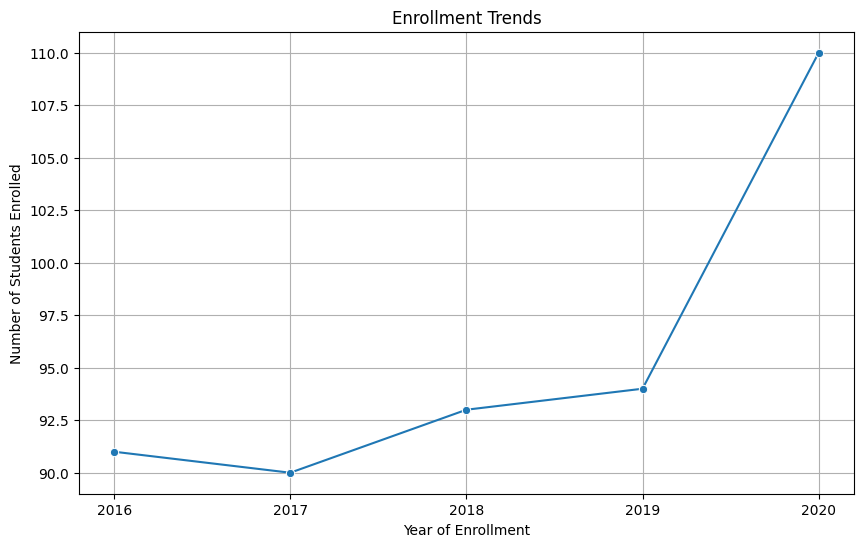

```python
import matplotlib.pyplot as plt
import seaborn as sns
import numpy as np

# Enrollment trends over the years
enrollment_trends = cs_data_sorted.groupby(
    'EnrollmentYear')['StudentID'].nunique().reset_index(name='Count')

# Plotting the enrollment trends
plt.figure(figsize=(10, 6))
sns.lineplot(x=enrollment_trends.EnrollmentYear,
             y=enrollment_trends.Count, marker='o')
plt.title('Enrollment Trends')
plt.xlabel('Year of Enrollment')
plt.ylabel('Number of Students Enrolled')
# xticks should be integers
plt.xticks(np.arange(2016, 2021, 1))
plt.grid(True)
plt.show()
```

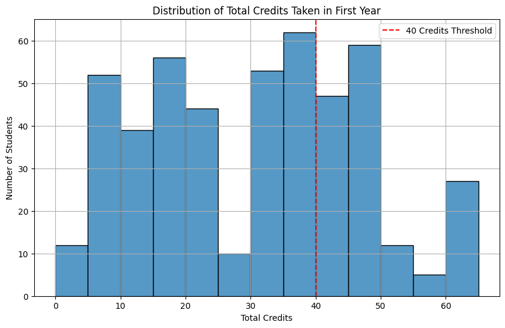

```python
# Creating a distribution of total credits taken by students in their first year

# Calculating the total credits for each student
total_credits_dist = first_year_data.groupby('StudentID')['Credits'].sum()

# Plotting the distribution of total credits
plt.figure(figsize=(10, 6))
sns.histplot(total_credits_dist, bins=range(0, 70, 5), kde=False)
plt.title('Distribution of Total Credits Taken in First Year')
plt.xlabel('Total Credits')
plt.ylabel('Number of Students')
plt.axvline(x=40, color='red', linestyle='--', label='40 Credits Threshold')
plt.legend()
plt.grid(True)
plt.show()
```

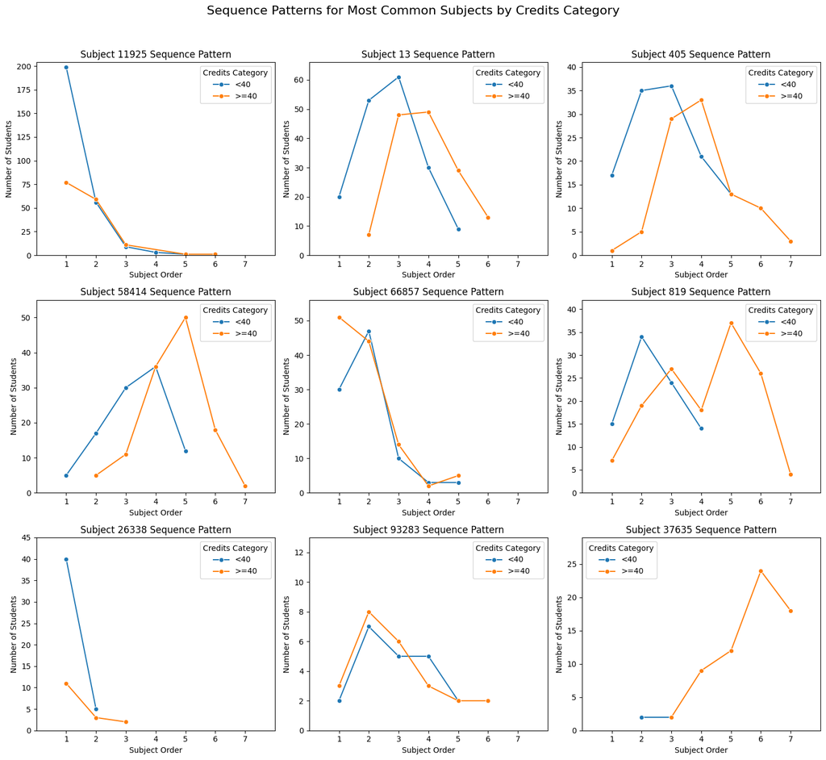

```python
# Preparing data for sequence pattern plots for each credit category

# Selecting the most common subjects for better visualization
top_subjects = most_common_subjects['SubjectID'].unique()

# Filtering data for the top subjects
sequence_pattern_data = sequence_sorted[sequence_sorted['SubjectID'].isin(top_subjects)]

# Plotting the sequence patterns for each credit category
plt.figure(figsize=(15, 13))
for i, subject_id in enumerate(top_subjects, 1):
    plt.subplot(3, 3, i)
    subject_sequence = sequence_pattern_data[sequence_pattern_data['SubjectID'] == subject_id]
    sns.lineplot(data=subject_sequence, x='SubjectOrder', y='Count', hue='CreditsCategory', marker='o')
    plt.title(f'Subject {int(subject_id)} Sequence Pattern')
    plt.xlabel('Subject Order')
    # ensure integer ticks
    plt.xticks(np.arange(1, 8, 1))
    # impose x limit
    plt.xlim(0, 8)
    plt.ylabel('Number of Students')
    plt.ylim(0, subject_sequence['Count'].max() + 5)
    plt.legend(title='Credits Category')
    plt.tight_layout()

plt.suptitle('Sequence Patterns for Most Common Subjects by Credits Category', fontsize=16, y=1.05)
plt.show()
```

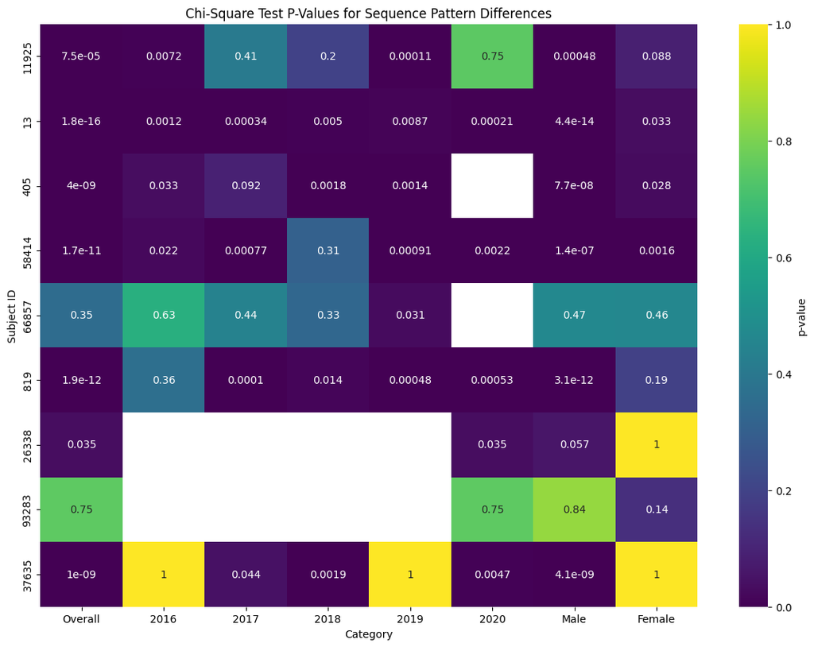

```python
# Preparing data for Chi-Square heatmaps

# Combining all p-values into a single DataFrame for visualization
p_values_combined = pd.DataFrame.from_dict(
    p_values, orient='index', columns=['Overall'])
p_values_combined['2016'] = pd.Series(p_values_for_all_years[2016])
p_values_combined['2017'] = pd.Series(p_values_for_all_years[2017])
p_values_combined['2018'] = pd.Series(p_values_for_all_years[2018])
p_values_combined['2019'] = pd.Series(p_values_for_all_years[2019])
p_values_combined['2020'] = pd.Series(p_values_for_all_years[2020])
p_values_combined['Male'] = pd.Series(p_values_by_gender['Male'])
p_values_combined['Female'] = pd.Series(p_values_by_gender['Female'])

# Plotting the heatmap
plt.figure(figsize=(14, 10))
sns.heatmap(p_values_combined, annot=True, fmt=".2g",
            cmap='viridis', cbar_kws={'label': 'p-value'})
plt.title('Chi-Square Test P-Values for Sequence Pattern Differences')
plt.xlabel('Category')
plt.ylabel('Subject ID')
plt.show()
```

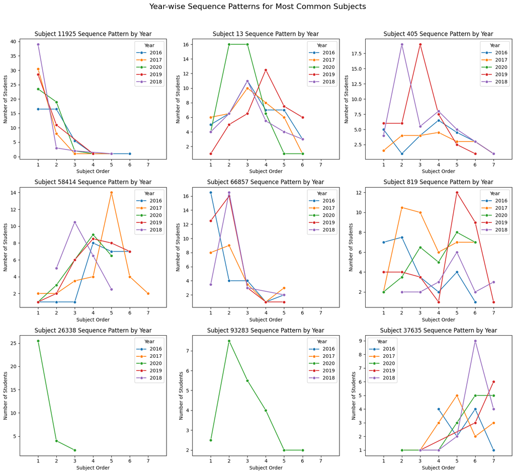

```python
# Year-wise sequence comparison plots for each common subject

plt.figure(figsize=(15, 13))
for i, subject_id in enumerate(top_subjects, 1):
    plt.subplot(3, 3, i)
    for year in enrollment_year_segments:
        # Selecting data for the specific year and subject
        year_data = sequence_analysis_by_year[year]
        year_subject_data = year_data[year_data['SubjectID'] == subject_id]
        # Plotting the sequence pattern for the year
        sns.lineplot(data=year_subject_data, x='SubjectOrder',
                     y='Count', label=str(year), marker='o', err_style=None)

    plt.title(f'Subject {int(subject_id)} Sequence Pattern by Year')
    plt.xlabel('Subject Order')
    # ensure integer ticks
    plt.xticks(np.arange(1, 8, 1))
    # impose x limit
    plt.xlim(0, 8)
    plt.ylabel('Number of Students')
    plt.legend(title='Year')
    plt.tight_layout()

plt.suptitle('Year-wise Sequence Patterns for Most Common Subjects',
             fontsize=16, y=1.05)
plt.show()
```

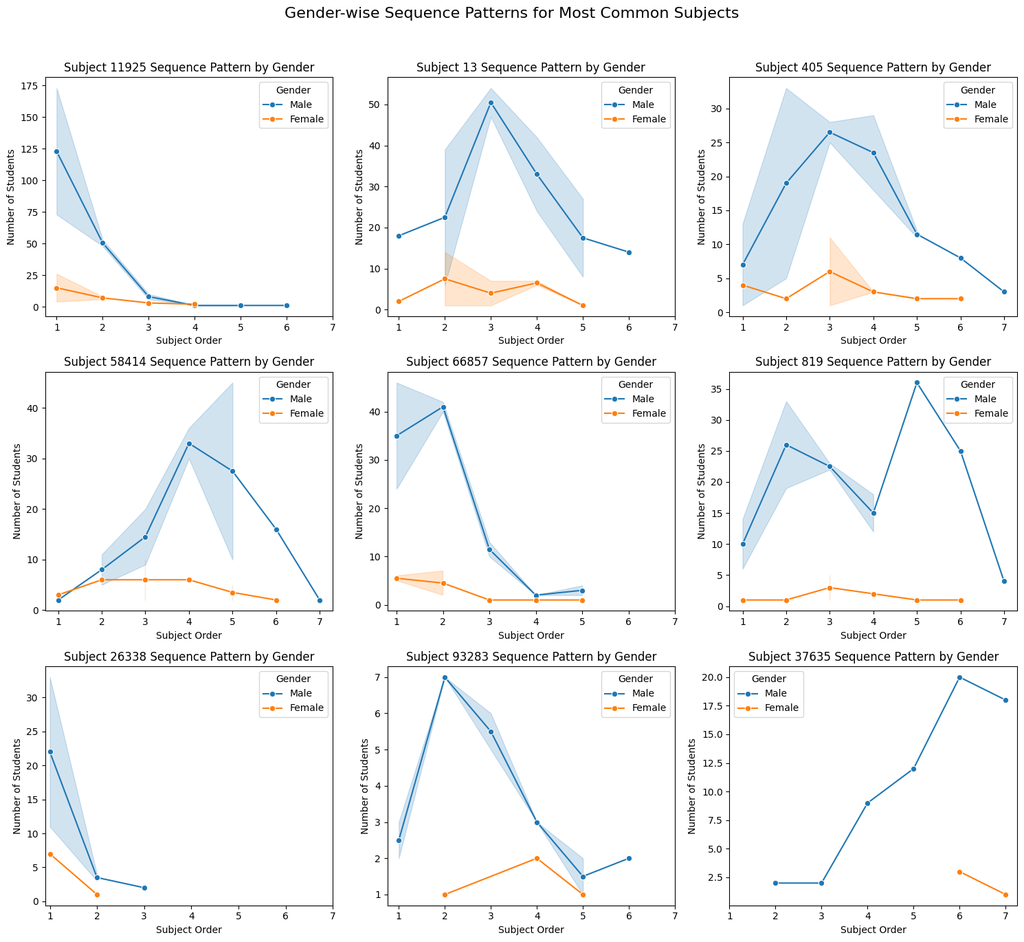

```python
# Gender-wise sequence comparison plots for each common subject

plt.figure(figsize=(15, 13))
for i, subject_id in enumerate(top_subjects, 1):
    plt.subplot(3, 3, i)
    for gender in gender_segments:
        # Selecting data for the specific gender and subject
        gender_data = sequence_analysis_by_gender[gender]
        gender_subject_data = gender_data[gender_data['SubjectID'] == subject_id]

        # Plotting the sequence pattern for the gender
        sns.lineplot(data=gender_subject_data, x='SubjectOrder',
                     y='Count', label=gender, marker='o')

    plt.title(f'Subject {int(subject_id)} Sequence Pattern by Gender')
    plt.xlabel('Subject Order')
    # ensure integer ticks
    plt.xticks(np.arange(1, 8, 1))
    plt.ylabel('Number of Students')
    plt.legend(title='Gender')
    plt.tight_layout()

plt.suptitle(
    'Gender-wise Sequence Patterns for Most Common Subjects', fontsize=16, y=1.05)
plt.show()
```